# Reproduce Weight as an Embodiment of Importance

## Why this study?

- Interesting hypothesis
- Straight experimental design
- Failures in the replications
- Check the original studies

## Hypothesis

- Abstract concept of **IMPORTANCE** is grounded in sensory experiences of **WEIGHT**
- Experiencing **WEIGHT** could influence judgments of **IMPORTANCE**
- Gain more gold from someone, give someone more credits.
- An industry contribute the most proportion to GDP, the government has to put more resource on this industry.

## Design: Apparent Spec

1. 35 cm X 23 cm X 4 cm
2. Light(empty): 657g; Heavy(add papers): 1,039g

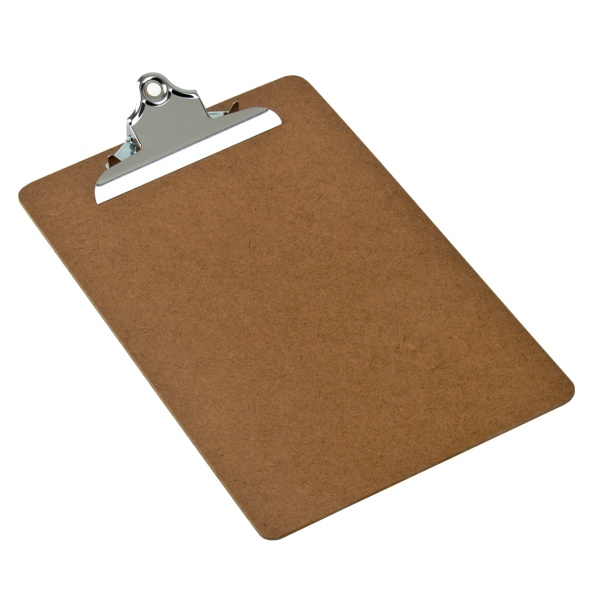

## Design: Goals of Studies

1. Judge the value of foreign currencies
2. Which voice (student, commit member) in decision-making procedures would be more important
3. Consistency of evaluating the city (Amsterdam) and evaluating the major
4. Agreement on the strong argument and weak argument for the community policy(Build subway staion in the campus)

## Findings

Holding heavy board performed more than holding light board on:  
1. the foreign currencies are more valuable  
2. the sudent's voice  
3. consistency of evaluations(higher correlation)  
4. extremely agree the strong arguments and extremely disagree the weak arguments

## Failures in the replications

- psychfiledrawer.org: Archives attempted replications of specific studies and whether replication was achieved.
- 5 replications on Jostmann, Lakens, and Schubert (2009)
- 1 successed; 4 failed

## Why we reproduce this study?

- Understand between-participant design
- Learn how to evaluate the sample size
- Exact replication vs. Conceputal replication
- Open the eye to pick up the study

## Between participant design

- Randomly assign the experimental treatments
- Whcih treatment could be assign? (Write up in your proposal)

## Random Assignment of Treatments

```r
N <- 40; set.seed(1); Assign <- sample(c("Heavy","Light"), N, replace = TRUE)
table(Assign)
```

```
## Assign
## Heavy Light
##    21    19
```

```r
names(Assign) <- 1:N
names(Assign)[Assign == "Heavy"]
```

```
##  [1] "1"  "2"  "5"  "10" "11" "12" "14" "16" "19" "22" "24" "25" "26" "27"
## [15] "28" "30" "31" "33" "34" "38" "40"
```

```r
names(Assign)[Assign == "Light"]
```

```
##  [1] "3"  "4"  "6"  "7"  "8"  "9"  "13" "15" "17" "18" "20" "21" "23" "29"
## [15] "32" "35" "36" "37" "39"
```

## Random Assignment of Treatments

- Could this treatment violate research ethic?
- Without harm for the participants after the study
- Has to be evaluated by IRB
- Check operative IRB websites: NTU, NCKU, FJU, …

## How to Evaluate Sample Size

1. Estimate the effect size
2. Compute the power by effect size
3. Decide the sample size by the effect size

## Estimate the effect size

*esComp()* in furncions.r  
We have this function from [RP:P project]

```
esComp <- function(
  x,
  df1,
  df2,
  N,
  esType){
  esComp <- ifelse(esType=="t",
                   sqrt((x^2*(1 / df2)) / (((x^2*1) / df2) + 1)),
                   ifelse(
                     esType=="F",
                     sqrt((x*(df1 / df2)) / (((x*df1) / df2) + 1))*sqrt(1/df1),
                     ifelse(
                       esType=="r",
                       x,
                       ifelse(
                         esType=="Chi2",
                         sqrt(x/N),
                         ifelse(
                           esType == "z",
                           tanh(x * sqrt(1/(N-3))),
                           NA
                         )
                       )
                     )
                   ))

  return(esComp)
}
```

## Estimate the effect size

```r
source("functions.r")
# Study 1
# N = 40
# F(1, 39) = 4.86
d.study1 <- esComp(4.86, 1, 39, 40, "F")
d.study1
```

```
## [1] 0.332877
```

## Compute the power by effect size

R package *pwr*

```r
require(pwr)
power.study1 <- pwr.anova.test(f=d.study1, k=2, n=40, sig.level=0.05)
power.study1
```

```
##
##      Balanced one-way analysis of variance power calculation
##
##               k = 2
##               n = 40
##               f = 0.332877
##       sig.level = 0.05
##           power = 0.8365881
##
## NOTE: n is number in each group
```

In the case without available sample size, we need the power to evaluate the sample size.

## Evluate the effect size by sample size

How large an effect size?

```
# Type this code in your console:
help(cohen.ES)
```

## Decide the sample size by the effect size

```r
n <- seq(10, 100, by = 10) # Expected number of participants in replication study
power <- pwr.anova.test(f=d.study1, k=2, n = n, sig.level=0.05)$power
rbind(n, power)
```

```
##             [,1]       [,2]       [,3]       [,4]       [,5]       [,6]
## n     10.0000000 20.0000000 30.0000000 40.0000000 50.0000000 60.0000000
## power  0.2914506  0.5366705  0.7175594  0.8365881  0.9092273  0.9512085
##             [,7]       [,8]       [,9]       [,10]
## n     70.0000000 80.0000000 90.0000000 100.0000000
## power  0.9744796  0.9869563  0.9934646   0.9967818
```

## Exact replication vs. Conceputal replication

- cited from [Diener & Biswas-Diener(2015)](http://nobaproject.com/modules/the-replication-crisis-in-psychology)
- **Exact replication:** A scientific attempt to *exactly copy the scientific methods used in an earlier study* in an effort to determine *whether the results are consistent*. The same—or similar—results are an indication that the findings are accurate.
- **Conceptual replication:** A scientific attempt to *copy the scientific hypothesis used in an earlier study* in an effort to determine *whether the results will generalize to different samples, times, or situations*. The same—or similar—results are an indication that the findings are generalizable.

## Will we have a exact replication?

- Can we copy all the details of method in the original study?
- Which treatment is impossible?
- Which measurement is impossible?

## Will we have a conceptual replication?

- Will the original hypothesis work when the conditions to gather data are different?
- Can we run the treatments and measurements in different samples, times or situations?

## Idea

[figure not shown]

## How to Write Proposal

- Introduction: Autopsy of the original study
1. Exact replication vs. Conceptual replication
2. Which Study (1,2,3,4)
3. Prediction
- Method
1. Sample: students in the campus; volunteers in the public circumstances
2. Treatments: Wight of Board; Questions
3. Measurement: Value; Agreement
4. Situation: in lab, outside lab